# R Notebook

Group members:Quan Nie,Zekun Gong,Yingjie Yun,Yunke Wang

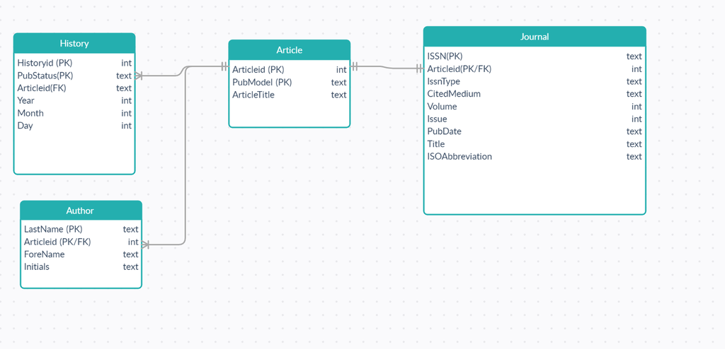

1.1relational schema is shown upon, and the sql instruction to create tables in the end of this page

```r
#link with sqlite database
library(RSQLite)
db<-dbConnect(SQLite(),dbname='sqlite.db')
```

for Question1, trying to put data from xml to r database, and put those tables in R write into Sql

```r
library(XML)
library(sqldf)
library(RCurl)
library(tidyr)
library(dplyr)
library(sparklyr)

parsed_doc<-xmlParse(file='new.xml',encoding='UTF-8',ignoreBlanks="True")

#table Article
PubModel<-xpathSApply(parsed_doc,'//PubmedArticleSet/PubmedArticle/MedlineCitation/Article',xmlGetAttr,"PubModel")
PubModel<-as.data.frame(PubModel)
Articleid<-seq(1,nrow(PubModel))
Article<-cbind(Articleid,PubModel)
ArticleTitle<-xpathSApply(parsed_doc,'//PubmedArticleSet/PubmedArticle/MedlineCitation/Article/ArticleTitle',xmlValue)
ArticleTitle<-as.data.frame(ArticleTitle)
Article<-cbind(Article,ArticleTitle)


#Table Author
Author<-xpathSApply(parsed_doc,'//PubmedArticleSet/PubmedArticle/MedlineCitation/Article/AuthorList',xmlSize)
Author1<-xpathSApply(parsed_doc,'//PubmedArticleSet/PubmedArticle/MedlineCitation/Article/AuthorList/Author/LastName',xmlValue)
Author1<-as.data.frame(Author1)
Author<-as.data.frame(Author)
#add corresponsing relationship between articleid and Lastname
count<-0
Articleid2<-data.frame("")
names(Articleid2)<-c("Articleid")
repeat{
count<-count+1
pre<-0
repeat{
  pre<-pre+1
  da<-data.frame(count)
names(da)<-c("Articleid")
Articleid2<-rbind(Articleid2,da)
  if(pre>=Author[count,])
  {break}
}

if(count>=19)
{break}

}
Articleid2<-Articleid2[-1,]
Articleid2<-as.data.frame(Articleid2)
Articleid2<-cbind(Articleid2,Author1)

ForeName<-xpathSApply(parsed_doc,'//PubmedArticleSet/PubmedArticle/MedlineCitation/Article/AuthorList/Author/ForeName',xmlValue)
ForeName<-as.data.frame(ForeName)

Initials<-xpathSApply(parsed_doc,'//PubmedArticleSet/PubmedArticle/MedlineCitation/Article/AuthorList/Author/Initials',xmlValue)
Articleid2<-cbind(Articleid2,ForeName)
Initials<-as.data.frame(Initials)
Articleid2<-cbind(Articleid2,Initials)
colnames(Articleid2)[2]<-'LastName'
colnames(Articleid2)[1]<-'Articleid'
Articleid2[,1]<-as.integer(Articleid2[,1])
Author2<-Articleid2
```

```r
#Table History
PubStatus<-xpathSApply(parsed_doc,'//PubmedArticleSet/PubmedArticle/PubmedData/History/PubMedPubDate',xmlGetAttr,"PubStatus")
PubStatus<-as.data.frame(PubStatus)
Historyid<-seq(1,nrow(PubStatus))
History<-cbind(PubStatus,Historyid)
Year<-xpathSApply(parsed_doc,'//PubmedArticleSet/PubmedArticle/PubmedData/History/PubMedPubDate/Year',xmlValue)
Year<-as.data.frame(Year)
Year[,1]<-as.integer(Year[,1])
History<-cbind(Year,History)
Month<-xpathSApply(parsed_doc,'//PubmedArticleSet/PubmedArticle/PubmedData/History/PubMedPubDate/Month',xmlValue)
Month<-as.data.frame(Month)
Month[,1]<-as.integer(Month[,1])
History<-cbind(Month,History)
Day<-xpathSApply(parsed_doc,'//PubmedArticleSet/PubmedArticle/PubmedData/History/PubMedPubDate/Day',xmlValue)
Day<-as.data.frame(Day)
Day[,1]<-as.integer(Day[,1])
History<-cbind(Day,History)

History1<-xpathSApply(parsed_doc,'//PubmedArticleSet/PubmedArticle/PubmedData/History',xmlSize)
History1<-as.data.frame(History1)
count<-0
Articleid1<-data.frame("")
names(Articleid1)<-c("H_Articleid")
repeat{
count<-count+1
pre<-0
repeat{
  pre<-pre+1
  da<-data.frame(count)
names(da)<-c("H_Articleid")
Articleid1<-rbind(Articleid1,da)
  if(pre>=History1[count,])
  {break}
}

if(count>=19)
{break}

}
Articleid1<-Articleid1[-1,]
Articleid1<-as.data.frame(Articleid1)
Articleid1<-cbind(Articleid1,History)
colnames(Articleid1)[1]<-'Articleid'
Articleid1[,1]<-as.integer(Articleid1[,1])
History<-Articleid1
```

```r
#table Journal
IssnType<-xpathSApply(parsed_doc,'//PubmedArticleSet/PubmedArticle/MedlineCitation/Article/Journal/ISSN',xmlGetAttr,"IssnType")
IssnType<-as.data.frame(IssnType)
CitedMedium<-xpathSApply(parsed_doc,'//PubmedArticleSet/PubmedArticle/MedlineCitation/Article/Journal/JournalIssue',xmlGetAttr,"CitedMedium")
CitedMedium<-as.data.frame(CitedMedium)
Journal<-cbind(IssnType,CitedMedium)
ISSN<-xpathSApply(parsed_doc,'//PubmedArticleSet/PubmedArticle/MedlineCitation/Article/Journal/ISSN',xmlValue)
ISSN<-as.data.frame(ISSN)
Journal<-cbind(ISSN,Journal)

Title<-xpathSApply(parsed_doc,'//PubmedArticleSet/PubmedArticle/MedlineCitation/Article/Journal/Title',xmlValue)
Title<-as.data.frame(Title)
Journal<-cbind(Title,Journal)

ISOAbbreviation<-xpathSApply(parsed_doc,'//PubmedArticleSet/PubmedArticle/MedlineCitation/Article/Journal/ISOAbbreviation',xmlValue)
ISOAbbreviation<-as.data.frame(ISOAbbreviation)
Journal<-cbind(ISOAbbreviation,Journal)

Volume<-xpathSApply(parsed_doc,'//PubmedArticleSet/PubmedArticle/MedlineCitation/Article/Journal/JournalIssue/Volume',xmlValue)
Volume<-as.data.frame(Volume)
Volume[,1]<-as.integer(Volume[,1])
Journal<-cbind(Volume,Journal)

Issue<-xpathSApply(parsed_doc,'//PubmedArticleSet/PubmedArticle/MedlineCitation/Article/Journal/JournalIssue/Issue',xmlValue)
Issue<-as.data.frame(Issue)
Issue[,1]<-as.integer(Issue[,1])
Journal<-cbind(Issue,Journal)

PubDate<-xpathSApply(parsed_doc,'//PubmedArticleSet/PubmedArticle/MedlineCitation/Article/Journal/JournalIssue/PubDate',xmlValue)
PubDate<-as.data.frame(PubDate)
Journal<-cbind(PubDate,Journal)
Articleid2<-seq(1,nrow(ISSN))
Journal<-cbind(Articleid2,Journal)
colnames(Journal)[1]<-'Articleid'
```

1.2 create tables in sql for the data written in 1.3transform data and load in, the tables would shown below

```sql
create table if not exists Article28(Articleid int,PubModel varchar(30),ArticleTitle varchar(255),primary key(PubModel,Articleid));
```

```r
#create table and write data into table
dbWriteTable(db,'Article28',Article,append=T)
```

```sql
create table if not exists History28(Historyid int,PubStatus varchar(30),Articleid int,Year int,Month int,Day int,constraint cid foreign key(Articleid)references Article28(Articleid),primary key(Historyid,PubStatus));
```

```r
dbWriteTable(db,'History28',History,append=T)
```

```sql
create table if not exists Author28(`LastName` varchar(30), `Articleid` int,`ForeName` Varchar(30),`Initials` Varchar(255),constraint eid foreign key(Articleid) references Article28(Articleid),primary key(Articleid,LastName));
```

```r
dbWriteTable(db,'Author28',Author2,append=T)
```

```sql
create table if not exists Journal28(ISSN varchar(255), Articleid int,IssnType varchar(255),CitedMedium varchar(255),Volume int,Issue int,PubDate varchar(255),Title varchar(255),ISOAbbreviation varchar(255),constraint fid foreign key(Articleid) references Article28(Articleid),primary key(ISSN,Articleid));
```

```r
dbWriteTable(db,'Journal28',Journal,append=T)
```

table Author

```sql
select * from Author28;
```

Displaying records 1 - 10

| LastName | Articleid | ForeName | Initials |
| --- | --- | --- | --- |
| Kuo | 1 | Cassie | C |
| Edwards | 1 | Alison | A |
| Mazumdar | 1 | Madhu | M |
| Memtsoudis | 1 | Stavros G | SG |
| Stundner | 2 | Ottokar | O |
| Kirksey | 2 | Meghan | M |
| Chiu | 2 | Ya Lin | YL |
| Mazumdar | 2 | Madhu | M |
| Poultsides | 2 | Lazaros | L |
| Gerner | 2 | Peter | P |

table Journal

```sql
select * from Journal28;
```

Displaying records 1 - 10

| ISSN | Articleid | IssnType | CitedMedium | Volume | Issue | PubDate | Title | ISOAbbreviation |
| --- | --- | --- | --- | --- | --- | --- | --- | --- |
| 1556-3316 | 1 | Print | Print | 8 | 2 | 2012Jul | HSS journal : the musculoskeletal journal of Hospital for Special Surgery | HSS J |
| 1545-7206 | 2 | Electronic | Internet | 54 | 2 | 2013 Mar-Apr | Psychosomatics | Psychosomatics |
| 1524-4628 | 3 | Electronic | Internet | 43 | 11 | 2012Nov | Stroke; a journal of cerebral circulation | Stroke |
| 1532-8651 | 4 | Electronic | Internet | 37 | 6 | 2012 Nov-Dec | Regional anesthesia and pain medicine | Reg Anesth Pain Med |
| 1532-2688 | 5 | Electronic | Internet | 22 | 1 | 2013Jan | Seizure : the journal of the British Epilepsy Association | Seizure |
| 1528-1132 | 6 | Electronic | Internet | 471 | 1 | 2013Jan | Clinical orthopaedics and related research | Clin. Orthop. Relat. Res. |
| 1532-8406 | 7 | Electronic | Internet | 27 | 10 | 2012Dec | The Journal of arthroplasty | J Arthroplasty |
| 1528-1175 | 8 | Electronic | Internet | 117 | 1 | 2012Jul | Anesthesiology | Anesthesiology |
| 1432-1998 | 9 | Electronic | Internet | 42 | 8 | 2012Aug | Pediatric radiology | Pediatr Radiol |
| 1530-0358 | 10 | Electronic | Internet | 55 | 4 | 2012Apr | Diseases of the colon and rectum | Dis. Colon Rectum |

table History

```sql
select * from History28;
```

Displaying records 1 - 10

| Historyid | PubStatus | Articleid | Year | Month | Day |
| --- | --- | --- | --- | --- | --- |
| 1 | received | 1 | 2012 | 1 | 15 |
| 2 | accepted | 1 | 2012 | 4 | 16 |
| 3 | epublish | 1 | 2012 | 6 | 20 |
| 4 | entrez | 1 | 2013 | 7 | 23 |
| 5 | pubmed | 1 | 2013 | 7 | 23 |
| 6 | medline | 1 | 2013 | 7 | 23 |
| 7 | received | 2 | 2012 | 7 | 16 |
| 8 | revised | 2 | 2012 | 8 | 17 |
| 9 | accepted | 2 | 2012 | 8 | 20 |
| 10 | aheadofprint | 2 | 2012 | 11 | 27 |

table Article

```sql
select * from Article28;
```

Displaying records 1 - 10

| Articleid | PubModel | ArticleTitle |
| --- | --- | --- |
| 1 | Print-Electronic | Regional anesthesia for children undergoing orthopedic ambulatory surgeries in the United States, 1996-2006. |
| 2 | Print-Electronic | Demographics and perioperative outcome in patients with depression and anxiety undergoing total joint arthroplasty: a population-based study. |
| 3 | Print | Cerebrovascular reserve and stroke risk in patients with carotid stenosis or occlusion: a systematic review and meta-analysis. |
| 4 | Print | Comparative perioperative outcomes associated with neuraxial versus general anesthesia for simultaneous bilateral total knee arthroplasty. |
| 5 | Print-Electronic | Vagus nerve stimulation vs. corpus callosotomy in the treatment of Lennox-Gastaut syndrome: a meta-analysis. |
| 6 | Print-Electronic | Have bilateral total knee arthroplasties become safer? A population-based trend analysis. |
| 7 | Print-Electronic | The metabolic syndrome in patients undergoing knee and hip arthroplasty: trends and in-hospital outcomes in the United States. |
| 8 | Print | Utilization of critical care services among patients undergoing total hip and knee arthroplasty: epidemiology and risk factors. |
| 9 | Print-Electronic | Visualization of the normal appendix with MR enterography in children. |
| 10 | Print | FDG-PET assessment of rectal cancer response to neoadjuvant chemoradiotherapy is not associated with long-term prognosis: a prospective evaluation. |

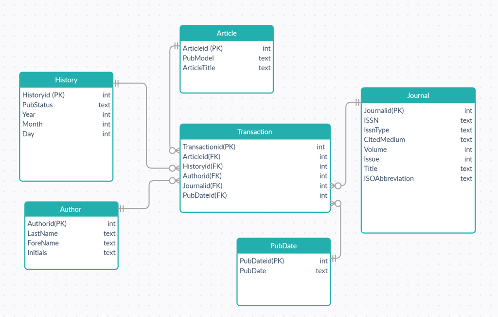

Question 2:2.1create star schema based on previous sql database.2.2there are five dimension tables and one fact table to be createn and populated

```sql
create table if not exists History01(Historyid int primary key,PubStatus varchar(30),Year int,Month int,Day int);
```

```sql
insert into History01 (Historyid,PubStatus,Year,Month,Day)select Historyid,PubStatus,Year,Month,Day from History28;
```

dimension table History

```sql
select * from History01;
```

Displaying records 1 - 10

| Historyid | PubStatus | Year | Month | Day |
| --- | --- | --- | --- | --- |
| 1 | received | 2012 | 1 | 15 |
| 2 | accepted | 2012 | 4 | 16 |
| 3 | epublish | 2012 | 6 | 20 |
| 4 | entrez | 2013 | 7 | 23 |
| 5 | pubmed | 2013 | 7 | 23 |
| 6 | medline | 2013 | 7 | 23 |
| 7 | received | 2012 | 7 | 16 |
| 8 | revised | 2012 | 8 | 17 |
| 9 | accepted | 2012 | 8 | 20 |
| 10 | aheadofprint | 2012 | 11 | 27 |

```sql
create table if not exists Article01(Articleid int primary key,PubModel varchar(30),ArticleTitle varchar(255));
```

```sql
insert into Article01(Articleid,PubModel,ArticleTitle) select Articleid,PubModel,ArticleTitle from Article28
```

dimension table Article

```sql
select * from Article01;
```

Displaying records 1 - 10

| Articleid | PubModel | ArticleTitle |
| --- | --- | --- |
| 1 | Print-Electronic | Regional anesthesia for children undergoing orthopedic ambulatory surgeries in the United States, 1996-2006. |
| 2 | Print-Electronic | Demographics and perioperative outcome in patients with depression and anxiety undergoing total joint arthroplasty: a population-based study. |
| 3 | Print | Cerebrovascular reserve and stroke risk in patients with carotid stenosis or occlusion: a systematic review and meta-analysis. |
| 4 | Print | Comparative perioperative outcomes associated with neuraxial versus general anesthesia for simultaneous bilateral total knee arthroplasty. |
| 5 | Print-Electronic | Vagus nerve stimulation vs. corpus callosotomy in the treatment of Lennox-Gastaut syndrome: a meta-analysis. |
| 6 | Print-Electronic | Have bilateral total knee arthroplasties become safer? A population-based trend analysis. |
| 7 | Print-Electronic | The metabolic syndrome in patients undergoing knee and hip arthroplasty: trends and in-hospital outcomes in the United States. |
| 8 | Print | Utilization of critical care services among patients undergoing total hip and knee arthroplasty: epidemiology and risk factors. |
| 9 | Print-Electronic | Visualization of the normal appendix with MR enterography in children. |
| 10 | Print | FDG-PET assessment of rectal cancer response to neoadjuvant chemoradiotherapy is not associated with long-term prognosis: a prospective evaluation. |

```sql
create table if not exists Author04(Authorid integer primary key Autoincrement , `LastName` varchar(30), `ForeName` Varchar(30),`Initials` Varchar(255));
```

```sql
insert into Author04 (LastName,ForeName,Initials) select distinct LastName, ForeName,Initials  from Author28;
```

dimension table Author

```sql
select * from Author04;
```

Displaying records 1 - 10

| Authorid | LastName | ForeName | Initials |
| --- | --- | --- | --- |
| 1 | Kuo | Cassie | C |
| 2 | Edwards | Alison | A |
| 3 | Mazumdar | Madhu | M |
| 4 | Memtsoudis | Stavros G | SG |
| 5 | Stundner | Ottokar | O |
| 6 | Kirksey | Meghan | M |
| 7 | Chiu | Ya Lin | YL |
| 8 | Poultsides | Lazaros | L |
| 9 | Gerner | Peter | P |
| 10 | Gupta | Ajay | A |

```sql
create table if not exists Journal02(Journalid integer primary key Autoincrement,ISSN varchar(255), IssnType varchar(255),CitedMedium varchar(255),Volume int,Issue int,Title varchar(255),ISOAbbreviation varchar(255));
```

```sql
insert into Journal02(ISSN,IssnType,CitedMedium,Volume,Issue,Title,ISOAbbreviation) select ISSN,IssnType,CitedMedium,Volume,Issue,Title,ISOAbbreviation from Journal28
```

dimension table Journal

```sql
select*from Journal02;
```

Displaying records 1 - 10

| Journalid | ISSN | IssnType | CitedMedium | Volume | Issue | Title | ISOAbbreviation |
| --- | --- | --- | --- | --- | --- | --- | --- |
| 1 | 1556-3316 | Print | Print | 8 | 2 | HSS journal : the musculoskeletal journal of Hospital for Special Surgery | HSS J |
| 2 | 1545-7206 | Electronic | Internet | 54 | 2 | Psychosomatics | Psychosomatics |
| 3 | 1524-4628 | Electronic | Internet | 43 | 11 | Stroke; a journal of cerebral circulation | Stroke |
| 4 | 1532-8651 | Electronic | Internet | 37 | 6 | Regional anesthesia and pain medicine | Reg Anesth Pain Med |
| 5 | 1532-2688 | Electronic | Internet | 22 | 1 | Seizure : the journal of the British Epilepsy Association | Seizure |
| 6 | 1528-1132 | Electronic | Internet | 471 | 1 | Clinical orthopaedics and related research | Clin. Orthop. Relat. Res. |
| 7 | 1532-8406 | Electronic | Internet | 27 | 10 | The Journal of arthroplasty | J Arthroplasty |
| 8 | 1528-1175 | Electronic | Internet | 117 | 1 | Anesthesiology | Anesthesiology |
| 9 | 1432-1998 | Electronic | Internet | 42 | 8 | Pediatric radiology | Pediatr Radiol |
| 10 | 1530-0358 | Electronic | Internet | 55 | 4 | Diseases of the colon and rectum | Dis. Colon Rectum |

```sql
create table if not exists PubDate01(PubDateid integer primary key Autoincrement,
PubDate varchar(255));
```

```sql
insert into PubDate01 (PubDate) select PubDate from Journal28;
```

dimension table PubDate

```sql
select*from PubDate01;
```

Displaying records 1 - 10

| PubDateid | PubDate |
| --- | --- |
| 1 | 2012Jul |
| 2 | 2013 Mar-Apr |
| 3 | 2012Nov |
| 4 | 2012 Nov-Dec |
| 5 | 2013Jan |
| 6 | 2013Jan |
| 7 | 2012Dec |
| 8 | 2012Jul |
| 9 | 2012Aug |
| 10 | 2012Apr |

```sql
Create table if not exists Transaction07(Transactionid integer primary key Autoincrement, Articleid int,Historyid int,Authorid int,Journalid int,PubDateid int,constraint id1 foreign key(Articleid) references Article01(Articleid),constraint id2 foreign key(Historyid) references History01(Historyid),constraint id3 foreign key(Authorid) references Author02(Authorid),constraint id4 foreign key(Journalid) references Journal02(Journalid),constraint id5 foreign key(PubDateid) references PubDate01(PubDateid))
```

```sql
insert into Transaction07 (Historyid,Articleid,Authorid,Journalid,PubDateid)
select History28.Historyid,Article01.Articleid,Author04.Authorid,Journal02.Journalid,Journal02.Journalid from History28 cross join Article01 on History28.Articleid=Article01.Articleid
cross join Author28 on Author28.Articleid=Article01.Articleid inner join Author04 on Author28.LastName=Author04.LastName and Author28.Initials=Author04.Initials cross join Journal28 on Journal28.Articleid=Article01.Articleid inner join Journal02 on Journal02.ISSN=Journal28.ISSN ;
```

fact table Transaction

```sql
select * from Transaction07;
```

Displaying records 1 - 10

| Transactionid | Articleid | Historyid | Authorid | Journalid | PubDateid |
| --- | --- | --- | --- | --- | --- |
| 1 | 1 | 1 | 2 | 1 | 1 |
| 2 | 1 | 1 | 1 | 1 | 1 |
| 3 | 1 | 1 | 3 | 1 | 1 |
| 4 | 1 | 1 | 4 | 1 | 1 |
| 5 | 1 | 2 | 2 | 1 | 1 |
| 6 | 1 | 2 | 1 | 1 | 1 |
| 7 | 1 | 2 | 3 | 1 | 1 |
| 8 | 1 | 2 | 4 | 1 | 1 |
| 9 | 1 | 3 | 2 | 1 | 1 |
| 10 | 1 | 3 | 1 | 1 | 1 |

For question3:3.1query numbers of publication per season. Firstly ,create season table and show query result per season. 3.2Secondly, show graph and comment on it.

```sql
create table season(winter int,spring int,summer int,autume);
```

```sql
select count(PubDateid) as winter from PubDate01 where PubDate like '%Dec%' or PubDate like '%Jan%' or pubDate like '%Feb%'
```

1 records

| winter |
| --- |
| 6 |

```sql
select count(PubDateid) as Spring from PubDate01 where PubDate like '%Mar%' or PubDate like '%Apr%' or pubDate like '%Mar%'
```

1 records

| Spring |
| --- |
| 4 |

```sql
select count(PubDateid) as Summer from PubDate01 where PubDate like '%Jun%' or PubDate like '%Jul%' or pubDate like '%Aug%'
```

1 records

| Summer |
| --- |
| 5 |

```sql
select count(PubDateid) as Autume from PubDate01 where PubDate like '%Sep%' or PubDate like '%Oct%' or pubDate like '%Nov%'
```

1 records

| Autume |
| --- |
| 3 |

```sql
create view iou as
select count(PubDateid) from PubDate01 where PubDate like '%Sep%' or PubDate like '%Oct%' or pubDate like '%Nov%'
```

```sql
insert into season (winter) select count(PubDateid) as winter from PubDate01 where PubDate like '%Dec%' or PubDate like '%Jan%' or pubDate like '%Feb%'
```

```sql
insert into season (spring)select count(PubDateid) as Spring from PubDate01 where PubDate like '%Mar%' or PubDate like '%Apr%' or pubDate like '%Mar%'
```

```sql
insert into season (summer)select count(PubDateid) as Summer from PubDate01 where PubDate like '%Jun%' or PubDate like '%Jul%' or pubDate like '%Aug%'
```

```sql
insert into season (autume)select count(PubDateid) as Autume from PubDate01 where PubDate like '%Sep%' or PubDate like '%Oct%' or pubDate like '%Nov%'
```

```sql
create view season1 as
select SUM(winter) as winter,SUM(spring) as spring,SUM(summer) as summer,SUM(autume) as autumn from season;
```

```sql
select * from season1;
```

1 records

| winter | spring | summer | autumn |
| --- | --- | --- | --- |
| 6 | 4 | 5 | 3 |

the result tells me:it shows seasonal pattern in fact, the Autumn is the season that it contributes to few publications. It give me an idea that the article is most likely to be published in Winter.

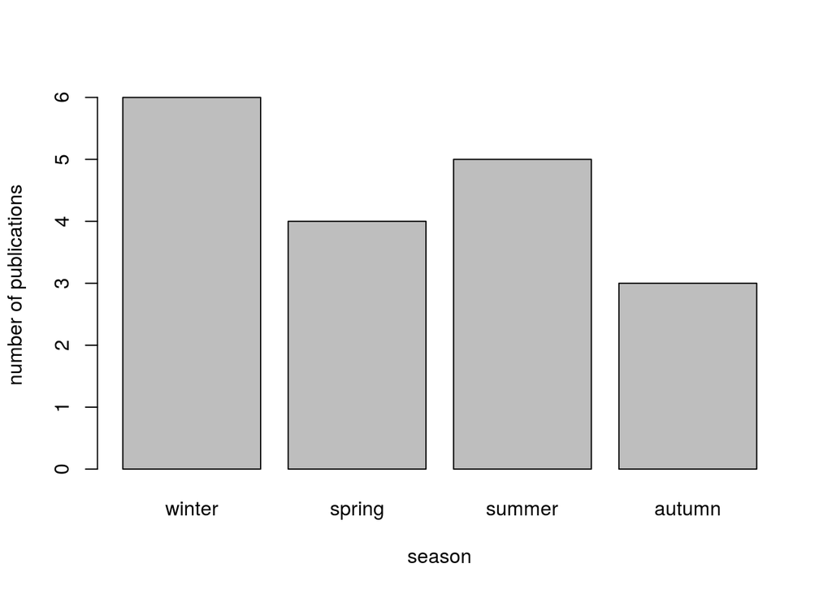

```r
H<-c(6,4,5,3)
M<-c("winter","spring","summer","autumn")
barplot(H,names.arg=M,xlab="season",ylab="number of publications")
```

the graph of numbers of publication per season